# Lab Session 2 - 3 Hours

# Convolutional Neural Network (CNN) for Handwritten Digits Recognition

**Student 1:** REY Romain **Student 2:** LABAISSE Hugo

The aim of this session is to practice with Convolutional Neural Networks. Answers and experiments should be made by groups of one or two students. Each group should fill and run appropriate notebook cells.

Once you have completed all of the code implementations and successfully answered each question above, you may finalize your work by exporting the iPython Notebook as an pdf document using print as PDF (Ctrl+P). Do not forget to run all your cells before generating your final report and do not forget to include the names of all participants in the group. The lab session should be completed by May 29th 2017.

Send you pdf file to benoit.huet@eurecom.fr and olfa.ben-ahmed@eurecom.fr using **[DeepLearning_lab2]** as Subject of your email.

# Introduction

In the last Lab Session, you built a Multilayer Perceptron for recognizing hand-written digits from the MNIST data-set. The best achieved accuracy on testing data was about 97%. Can you do better than these results using a deep CNN ? In this Lab Session, you will build, train and optimize in TensorFlow one of the early Convolutional Neural Networks: **LeNet-5** to go to more than 99% of accuracy.

# Load MNIST Data in TensorFlow

Run the cell above to load the MNIST data that comes with TensorFlow. You will use this data in **Section 1** and **Section 2**.

```python
import tensorflow as tf
from tensorflow.examples.tutorials.mnist import input_data
mnist = input_data.read_data_sets("MNIST_data/", one_hot=True)
X_train, y_train           = mnist.train.images, mnist.train.labels
X_validation, y_validation = mnist.validation.images, mnist.validation.labels
X_test, y_test             = mnist.test.images, mnist.test.labels
print("Image Shape: {}".format(X_train[0].shape))
print("Training Set:   {} samples".format(len(X_train)))
print("Validation Set: {} samples".format(len(X_validation)))
print("Test Set:       {} samples".format(len(X_test)))
```

```
Extracting MNIST_data/train-images-idx3-ubyte.gz
Extracting MNIST_data/train-labels-idx1-ubyte.gz
Extracting MNIST_data/t10k-images-idx3-ubyte.gz
Extracting MNIST_data/t10k-labels-idx1-ubyte.gz
Image Shape: (784,)
Training Set:   55000 samples
Validation Set: 5000 samples
Test Set:       10000 samples
```

# Section 1 : My First Model in TensorFlow

Before starting with CNN, let's train and test in TensorFlow the example : **y=softmax(Wx+b)** seen in the DeepLearing course last week.

This model reaches an accuracy of about 92 %. You will also learn how to launch the tensorBoard https://www.tensorflow.org/get_started/summaries_and_tensorboard to visualize the computation graph, statistics and learning curves.

**Part 1** : Read carefully the code in the cell below. Run it to perform training.

```python
from __future__ import print_function
import tensorflow as tf


#STEP 1

# Parameters
learning_rate = 0.01
training_epochs = 100
batch_size = 128
display_step = 1
logs_path = 'log_files/'  # useful for tensorboard

# tf Graph Input:  mnist data image of shape 28*28=784
x = tf.placeholder(tf.float32, [None, 784], name='InputData')
# 0-9 digits recognition,  10 classes
y = tf.placeholder(tf.float32, [None, 10], name='LabelData')

# Set model weights
W = tf.Variable(tf.zeros([784, 10]), name='Weights')
b = tf.Variable(tf.zeros([10]), name='Bias')

# Construct model and encapsulating all ops into scopes, making Tensorboard's Graph visualization more convenient
with tf.name_scope('Model'):
    # Model
    pred = tf.nn.softmax(tf.matmul(x, W) + b) # Softmax
with tf.name_scope('Loss'):
    # Minimize error using cross entropy
    cost = tf.reduce_mean(-tf.reduce_sum(y*tf.log(pred), reduction_indices=1))
with tf.name_scope('SGD'):
    # Gradient Descent
    optimizer = tf.train.GradientDescentOptimizer(learning_rate).minimize(cost)
with tf.name_scope('Accuracy'):
    # Accuracy
    acc = tf.equal(tf.argmax(pred, 1), tf.argmax(y, 1))
    acc = tf.reduce_mean(tf.cast(acc, tf.float32))

# Initializing the variables
init = tf.global_variables_initializer()
# Create a summary to monitor cost tensor
tf.summary.scalar("Loss", cost)
# Create a summary to monitor accuracy tensor
tf.summary.scalar("Accuracy", acc)
# Merge all summaries into a single op
merged_summary_op = tf.summary.merge_all()


#STEP 2


# Launch the graph for training
with tf.Session() as sess:
    sess.run(init)
    # op to write logs to Tensorboard
    summary_writer = tf.summary.FileWriter(logs_path, graph=tf.get_default_graph())
    # Training cycle
    for epoch in range(training_epochs):
        avg_cost = 0.
        total_batch = int(mnist.train.num_examples/batch_size)
        # Loop over all batches
        for i in range(total_batch):
            batch_xs, batch_ys = mnist.train.next_batch(batch_size)
            # Run optimization op (backprop), cost op (to get loss value)
            # and summary nodes
            _, c, summary = sess.run([optimizer, cost, merged_summary_op],
                                     feed_dict={x: batch_xs, y: batch_ys})
            # Write logs at every iteration
            summary_writer.add_summary(summary, epoch * total_batch + i)
            # Compute average loss
            avg_cost += c / total_batch
        # Display logs per epoch step
        if (epoch+1) % display_step == 0:
            print("Epoch: ", '%02d' % (epoch+1), "  =====> Loss=", "{:.9f}".format(avg_cost))

    print("Optimization Finished!")

    # Test model
    # Calculate accuracy
    print("Accuracy:", acc.eval({x: mnist.test.images, y: mnist.test.labels}))
```

```
Epoch:  01   =====> Loss= 1.286880517
Epoch:  02   =====> Loss= 0.732117994
Epoch:  03   =====> Loss= 0.600037868
Epoch:  04   =====> Loss= 0.536467825
Epoch:  05   =====> Loss= 0.497685938
Epoch:  06   =====> Loss= 0.471141003
Epoch:  07   =====> Loss= 0.451228836
Epoch:  08   =====> Loss= 0.435966311
Epoch:  09   =====> Loss= 0.423321287
Epoch:  10   =====> Loss= 0.413150285
Epoch:  11   =====> Loss= 0.404392284
Epoch:  12   =====> Loss= 0.396793319
Epoch:  13   =====> Loss= 0.390509525
Epoch:  14   =====> Loss= 0.384444750
Epoch:  15   =====> Loss= 0.379388295
Epoch:  16   =====> Loss= 0.374496932
Epoch:  17   =====> Loss= 0.369893666
Epoch:  18   =====> Loss= 0.366108617
Epoch:  19   =====> Loss= 0.362956739
Epoch:  20   =====> Loss= 0.359653829
Epoch:  21   =====> Loss= 0.356535504
Epoch:  22   =====> Loss= 0.353688750
Epoch:  23   =====> Loss= 0.351177553
Epoch:  24   =====> Loss= 0.348700343
Epoch:  25   =====> Loss= 0.346541883
Epoch:  26   =====> Loss= 0.344281041
Epoch:  27   =====> Loss= 0.342153159
Epoch:  28   =====> Loss= 0.340112898
Epoch:  29   =====> Loss= 0.338629775
Epoch:  30   =====> Loss= 0.336706358
Epoch:  31   =====> Loss= 0.335196832
Epoch:  32   =====> Loss= 0.333376968
Epoch:  33   =====> Loss= 0.331833864
Epoch:  34   =====> Loss= 0.330573238
Epoch:  35   =====> Loss= 0.329193066
Epoch:  36   =====> Loss= 0.327743336
Epoch:  37   =====> Loss= 0.326489333
Epoch:  38   =====> Loss= 0.325297339
Epoch:  39   =====> Loss= 0.324059522
Epoch:  40   =====> Loss= 0.323147468
```

[output cut: 47 more lines]

```
Epoch:  88   =====> Loss= 0.293990625
Epoch:  89   =====> Loss= 0.293439280
Epoch:  90   =====> Loss= 0.293092630
Epoch:  91   =====> Loss= 0.292830179
Epoch:  92   =====> Loss= 0.292316929
Epoch:  93   =====> Loss= 0.292202655
Epoch:  94   =====> Loss= 0.291806372
Epoch:  95   =====> Loss= 0.291340222
Epoch:  96   =====> Loss= 0.291281088
Epoch:  97   =====> Loss= 0.290975091
Epoch:  98   =====> Loss= 0.290458739
Epoch:  99   =====> Loss= 0.290398429
Epoch:  100   =====> Loss= 0.290065766
Optimization Finished!
Accuracy: 0.92
```

**Part 2** : Using Tensorboard, we can now visualize the created graph, giving you an overview of your architecture and how all of the major components are connected. You can also see and analyse the learning curves.

To launch tensorBoard:

- Go to the **TP2** folder,
- Open a Terminal and run the command line **"tensorboard --logdir= log_files/"**, it will generate an http link ,ex http://666.6.6.6:6006,
- Copy this link into your web browser

Enjoy It !!

# Section 2 : The 99% MNIST Challenge !

**Part 1** : LeNet5 implementation

One you are now familar with **tensorFlow** and **tensorBoard**, you are in this section to build, train and test the baseline [LeNet-5](http://yann.lecun.com/exdb/lenet/) model for the MNIST digits recognition problem.

In more advanced step you will make some optimizations to get more than 99% of accuracy. The best model can get to over 99.7% accuracy!

For more information, have a look at this list of results : http://rodrigob.github.io/are_we_there_yet/build/classification_datasets_results.html

Figure 1: Lenet 5

The LeNet architecture accepts a 32x32xC image as input, where C is the number of color channels. Since MNIST images are grayscale, C is 1 in this case.

**Layer 1: Convolutional.** The output shape should be 28x28x6 **Activation.** sigmoid **Pooling.** The output shape should be 14x14x6.

**Layer 2: Convolutional.** The output shape should be 10x10x16. **Activation.** sigmoid **Pooling.** The output shape should be 5x5x16.

**Flatten.** Flatten the output shape of the final pooling layer such that it's 1D instead of 3D. You may need to use **flatten* from tensorflow.contrib.layers import flatten

**Layer 3: Fully Connected.** This should have 120 outputs. **Activation.** sigmoid

**Layer 4: Fully Connected.** This should have 84 outputs. **Activation.** sigmoid

**Layer 5: Fully Connected.** This should have 10 outputs. **softmax**

**Question 2.1.1** Implement the Neural Network architecture described above. For that, your will use classes and functions from https://www.tensorflow.org/api_docs/python/tf/nn.

We give you some helper functions for weigths and bias initilization. Also you can refer to section 1.

```python
import tensorflow as tf
from tensorflow.examples.tutorials.mnist import input_data
mnist = input_data.read_data_sets("MNIST_data/", one_hot=True)
X_train, y_train           = mnist.train.images, mnist.train.labels
X_validation, y_validation = mnist.validation.images, mnist.validation.labels
X_test, y_test             = mnist.test.images, mnist.test.labels
print("Image Shape: {}".format(X_train[0].shape))
print("Training Set:   {} samples".format(len(X_train)))
print("Validation Set: {} samples".format(len(X_validation)))
print("Test Set:       {} samples".format(len(X_test)))
```

```
Extracting MNIST_data/train-images-idx3-ubyte.gz
Extracting MNIST_data/train-labels-idx1-ubyte.gz
Extracting MNIST_data/t10k-images-idx3-ubyte.gz
Extracting MNIST_data/t10k-labels-idx1-ubyte.gz
Image Shape: (784,)
Training Set:   55000 samples
Validation Set: 5000 samples
Test Set:       10000 samples
```

```python
#Helper functions  for weigths and bias initilization

def weight_variable(shape):
  initial = tf.truncated_normal(shape, stddev=0.1)
  return tf.Variable(initial)

def bias_variable(shape):
  initial = tf.constant(0.1, shape=shape)
  return tf.Variable(initial)
```

```python
from tensorflow.contrib.layers import flatten
from tensorflow.contrib.layers import fully_connected

def LeNet5_Model(dataNotReshaped):
    data = tf.reshape(dataNotReshaped,shape=[-1,28,28,1])
    # Set model weights
    W1,W2 = weight_variable([5,5,1,6]),weight_variable([5,5,6,16])
    b1,b2 = bias_variable([6]),bias_variable([16])
    W3 = weight_variable([400,120])
    b3 = bias_variable([120])
    W4 = weight_variable([120,84])
    b4 = bias_variable([84])
    W5 = weight_variable([84,10])
    b5 = bias_variable([10])


    with tf.name_scope('Model'):
        #Layer1 Convolution
        layer1a=tf.nn.convolution(data,W1,strides=[1,1],padding="SAME")
        layer1b=tf.nn.bias_add(layer1a,b1)
            #for the relu function
        layer1b1 = tf.nn.relu(layer1b)
        #Layer1 pooling
        layer1c =tf.nn.max_pool(layer1b1,ksize=[1, 2, 2, 1],strides=[1, 2, 2, 1],padding='SAME', name='pool1')

        #Layer2 Convolution
        layer2a=tf.nn.convolution(layer1c,W2,strides=[1,1],padding="VALID")
        layer2b=tf.nn.bias_add(layer2a,b2)
            #for the relu function
        layer2b1 = tf.nn.relu(layer2b)
        #Layer2 pooling
        layer2c =tf.nn.max_pool(layer2b1,ksize=[1, 2, 2, 1],strides=[1, 2, 2, 1],padding='SAME', name='pool2')
        print(layer2c)

        #flatten
        flattened = flatten(layer2c)

        #Layer 3 Fully connected
            #for the relu function
        layer3 = tf.nn.relu(tf.matmul(flattened, W3) + b3)
            #for the sigmoid function
        #layer3 = tf.nn.sigmoid(tf.nn.softmax(tf.matmul(flattened, W3) + b3))

        # Layer 4 Fully connected
            #for the relu function
        layer4 = tf.nn.relu(tf.matmul(layer3, W4) + b4)
            #for the sigmoid function
        #layer4 = tf.nn.sigmoid(tf.nn.softmax(tf.matmul(layer3, W4) + b4))

        #Layer 5
        layer5 = tf.nn.sigmoid(tf.nn.softmax(tf.matmul(layer4, W5) + b5))
        layer5 = tf.nn.dropout(layer5, 0.75)

    return layer5
```

**Question 2.1.2.** Calculate the number of parameters of this model

```python
s=0
s+=5*5*1*6 #Weight first convolution
s+=5*5*6*16 #Weight second convolution
s+=6 #Bias 1
s+=16 #Bias 2
s+=160*120 #Weight 1st fully connected layer
s+=120*84 #Weight 2nd fully connected layer
s+=84*10 #Weight 3rd fully connected layer
print('Number of parameter in this model is:', s)
```

[output not shown]

**Question 2.1.3.** Start the training with the parameters cited below:

```
 Learning rate =0.1
 Loss Fucntion : Cross entropy
 Optimisateur: SGD
 Number of training iterations= 10000
 The batch size =128
```

```python
# Training parameters
l_rate =0.001
n_iterations= 100
batch_size = 128
display_step = 10

#Your implementation goes here
# tf Graph Input:  mnist data image of shape 28*28=784
# 0-9 digits recognition,  10 classes
x = tf.placeholder(tf.float32, [None, 784], name='InputData2')\
# 0-9 digits recognition,  10 classes
y = tf.placeholder(tf.float32, [None, 10], name='LabelData')


# Construct model and encapsulating all ops into scopes, making Tensorboard's Graph visualization more convenient
with tf.name_scope('Model'):
    pred = LeNet5_Model(x)
with tf.name_scope('Loss'):
# Minimize error using cross entropy
    cost = tf.reduce_mean(tf.nn.softmax_cross_entropy_with_logits(logits=pred, labels=y))
with tf.name_scope('SGD'):
# Gradient Descent
    #optimizer = tf.train.GradientDescentOptimizer(l_rate).minimize(cost)
    optimizer = tf.train.AdamOptimizer(l_rate).minimize(cost) #for Adam optimizer
with tf.name_scope('Accuracy'):
        acc = evaluate(pred,y)
```

```
Tensor("Model_3/Model/pool2:0", shape=(?, 5, 5, 16), dtype=float32)
```

**Question 2.1.4.** Implement the evaluation function for accuracy computation

```python
def evaluate(model, y):
    acc = tf.equal(tf.argmax(model, 1), tf.argmax(y, 1))
    acc = tf.reduce_mean(tf.cast(acc, tf.float32))
    return acc
```

**Question 2.1.5.** Implement training pipeline and run the training data through it to train the model.

- Before each epoch, shuffle the training set.
- Print the loss per mini batch and the training/validation accuracy per epoch. (Display results every 100 epochs)
- Save the model after training
- Print after training the final testing accuracy

```python
import numpy as np
from __future__ import print_function
import tensorflow as tf
import time



logs_path = 'log_files/'
# Initializing the variables
init = tf.global_variables_initializer()
# Create a summary to monitor cost tensor
tf.summary.scalar("Loss", cost)
# Create a summary to monitor accuracy tensor
tf.summary.scalar("Accuracy", acc)
eval_list = []

def train(pred, batch_size,optimizer,cost,init,training_epochs):
    # Initializing the session

    # Launch the graph for training
    print ("Start Training!")
    t1 = time.clock()
    with tf.Session() as sess:
        sess.run(init)

        #Save our model
        save = tf.train.Saver()

        total_batch = int(mnist.train.num_examples/batch_size)
        # Training cycle
        for epoch in range(training_epochs):
            avg_cost = 0.

            # Loop over all batches
            for i in range(total_batch):

                batch_xs, batch_ys = mnist.train.next_batch(batch_size)

                # Run optimization op (backprop), cost op (to get loss value)
                _, c = sess.run([optimizer, cost],
                                         feed_dict={x: batch_xs, y: batch_ys})
                # Compute average loss
                avg_cost += c / total_batch
            # Display logs per epoch step
            if (epoch+1) % display_step == 0:
                print("Epoch: ", '%02d' % (epoch+1), "  =====> Loss=", "{:.9f}".format(avg_cost))
                print("Accuracy on validation data:",acc.eval({x: mnist.validation.images, y: mnist.validation.labels}))
        print ("Training Finished!")
        print('Training time:', t1-time.clock())

   #Your implementation for testing accuracy after training goes here
    print("Accuracy:", acc.eval({x: mnist.test.images, y: mnist.test.labels}))

    return save
```

```python
save = train(pred, batch_size,optimizer,cost,init,n_iterations)
```

[output not shown]

```python
save = train(pred, batch_size,optimizer,cost,init,n_iterations)
```

**Question 2.1.6** : Use tensorBoard to visualise and save the LeNet5 Graph and all learning curves. Save all obtained figures in the folder **"TP2/MNIST_99_Challenge_Figures"**

**Part 2** : LeNET 5 Optimization

**Question 2.2.1** Change the sigmoid function with a Relu :

- Retrain your network with SGD and AdamOptimizer and then fill the table above :

[output not shown]

- Try with different learning rates for each Optimizer (0.0001 and 0.001 ) and different Batch sizes (50 and 128) for 20000 Epochs.
- For each optimizer, plot (on the same curve) the **testing accuracies** function to **(learning rate, batch size)**
- Did you reach the 99% accuracy ? What are the optimal parametres that gave you the best results?

### With the relu function

```python
#When modified with the relu function
save2 = train(pred, batch_size,optimizer,cost,init,200)
#Just put tf.nn.relu instead of sigmoid
#optimizer = tf.train.AdamOptimizer(l_rate).minimize(cost) for Adam optimizer
```

```
Start Training!
Epoch:  10   =====> Loss= 2.169254462
Accuracy on validation data: 0.689
Epoch:  20   =====> Loss= 2.166957922
Accuracy on validation data: 0.6998
Epoch:  30   =====> Loss= 2.166051349
Accuracy on validation data: 0.7006
Epoch:  40   =====> Loss= 2.165472396
Accuracy on validation data: 0.7032
Epoch:  50   =====> Loss= 2.150276400
Accuracy on validation data: 0.802
Epoch:  60   =====> Loss= 2.123249830
Accuracy on validation data: 0.8956
Epoch:  70   =====> Loss= 2.121934907
Accuracy on validation data: 0.9002
Epoch:  80   =====> Loss= 2.121249557
Accuracy on validation data: 0.9
Epoch:  90   =====> Loss= 2.120830013
Accuracy on validation data: 0.9004
Epoch:  100   =====> Loss= 2.120526731
Accuracy on validation data: 0.901
Epoch:  110   =====> Loss= 2.120249864
Accuracy on validation data: 0.9014
Epoch:  120   =====> Loss= 2.120024871
Accuracy on validation data: 0.9024
Epoch:  130   =====> Loss= 2.119825777
Accuracy on validation data: 0.9018
Epoch:  140   =====> Loss= 2.119665040
Accuracy on validation data: 0.9032
Epoch:  150   =====> Loss= 2.119627205
Accuracy on validation data: 0.903
Epoch:  160   =====> Loss= 2.119528596
Accuracy on validation data: 0.9034
Epoch:  170   =====> Loss= 2.119490841
Accuracy on validation data: 0.903
Epoch:  180   =====> Loss= 2.119391080
Accuracy on validation data: 0.9036
Epoch:  190   =====> Loss= 2.119334818
Accuracy on validation data: 0.9036
Epoch:  200   =====> Loss= 2.119297108
Accuracy on validation data: 0.9032
Training Finished!
Training time: -11376.810393
```

[output not shown]

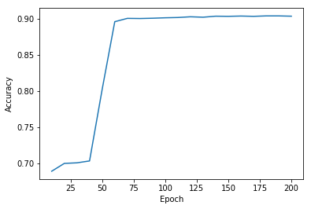

```python
import matplotlib.pyplot as plt

epoch = [i for i in range(10, 210, 10)]
accuracy = [0.689, 0.6998, 0.7006, 0.7032, 0.802, 0.8956, 0.9002, 0.9, 0.9004, 0.901, 0.9014, 0.9024, 0.9018, 0.9032,
            0.903, 0.9034, 0.903, 0.9036, 0.9036, 0.9032]

plt.xlabel('Epoch')
plt.ylabel('Accuracy')
plt.plot(epoch, accuracy)
plt.show()
```

The accuracy on test data doesn't compute but we don't know why.  
With the relu function we obtain better result. Indeed we obtain 90% of accuracy after only 200 epoch. Moreover our loss decreases and our accuracy increases over the epoch. Of course it will be better after the 10000 epochs but we didn't have time for that because our algorithm is very slow.

### With Adam Optimizer

Start Training!  
Epoch: 10 =====> Loss= 2.305314260 Accuracy on validation data: 0.099  
Epoch: 20 =====> Loss= 2.305326885 Accuracy on validation data: 0.099  
Epoch: 30 =====> Loss= 2.305339494 Accuracy on validation data: 0.099  
Epoch: 40 =====> Loss= 2.305339513 Accuracy on validation data: 0.099  
Epoch: 50 =====> Loss= 2.305356344 Accuracy on validation data: 0.099  
Epoch: 60 =====> Loss= 2.305343715 Accuracy on validation data: 0.099  
Epoch: 70 =====> Loss= 2.305360542 Accuracy on validation data: 0.099  
Epoch: 80 =====> Loss= 2.305335290 Accuracy on validation data: 0.099  
Epoch: 90 =====> Loss= 2.305322666 Accuracy on validation data: 0.099  
Epoch: 100 =====> Loss= 2.305352125 Accuracy on validation data: 0.099  
Training Finished!

**Question 2.2.2** What about applying a dropout layer on the Fully conntected layer and then retraining the model with the best Optimizer and parameters(Learning rate and Batsh size) obtained in *Question 2.2.1* ? (probability to keep units=0.75). For this stage ensure that the keep prob is set to 1.0 to evaluate the performance of the network including all nodes.

```python
# your implementaion goas here
save2 = train(pred, batch_size,optimizer,cost,init,100)
# tf.nn.dropout(layer5, 0.75)
```

```
Start Training!
Epoch:  10   =====> Loss= 2.100850424
Accuracy on validation data: 0.9854
Epoch:  20   =====> Loss= 2.099293877
Accuracy on validation data: 0.989
Epoch:  30   =====> Loss= 2.098683649
Accuracy on validation data: 0.9892
Epoch:  40   =====> Loss= 2.098559357
Accuracy on validation data: 0.9886
Epoch:  50   =====> Loss= 2.098518921
Accuracy on validation data: 0.9872
Epoch:  60   =====> Loss= 2.098118405
Accuracy on validation data: 0.9878
Epoch:  70   =====> Loss= 2.098169094
Accuracy on validation data: 0.9906
Epoch:  80   =====> Loss= 2.098103995
Accuracy on validation data: 0.9886
Epoch:  90   =====> Loss= 2.098323639
Accuracy on validation data: 0.9898
Epoch:  100   =====> Loss= 2.098024817
Accuracy on validation data: 0.9906
Training Finished!
Training time: -6290.880262
```

Adding a dropout layer on the last fully connected layer is good, indeed it increases a lot our accuracy on validation data. Moreover we reached the goal of 99% accuracy on validation data.